# NYPD Shooting Incident Data 2006 - 2020

John Doe

16/5/2021

```r
library(tidyverse)
library(readr)

nypd_data <- read_csv("https://data.cityofnewyork.us/api/views/833y-fsy8/rows.csv?accessType=DOWNLOAD")
```

# 1 NYPD Police Shooting Dataset

List of every shooting incident that occurred in NYC going back to 2006 through the end of the previous calendar year.

The dataset represents every shooting incident that occurred in NYC going back to 2006 through the end of the previous calendar year. This data is manually extracted every quarter and reviewed by the Office of Management Analysis and Planning before being posted on the NYPD website. Each record represents a shooting incident in NYC and includes information about the event, the location and time of occurrence. In addition, information related to suspect and victim demographics is also included.

## 1.1 Goal of this Analyis

This analysis aims to understand better the victims of gun violence in NYC and which groups are most affected. For that purpose, this report shows which district, time of the year, time of the day, gender, and age group is affected most by reported/detected gun violence in NYC between 2006 and 2020.

## 1.2 Description of the Data

The Dataset at hand has 23.568 rows and 19 columns. You can find more summary information in the following code block. For more information regarding the column description, please consult ‘https://data.cityofnewyork.us/Public-Safety/NYPD-Shooting-Incident-Data-Historic-/833y-fsy8’

```r
summary(nypd_data)
```

```
##   INCIDENT_KEY        OCCUR_DATE         OCCUR_TIME           BORO
##  Min.   :  9953245   Length:23568       Length:23568      Length:23568
##  1st Qu.: 55317014   Class :character   Class1:hms        Class :character
##  Median : 83365370   Mode  :character   Class2:difftime   Mode  :character
##  Mean   :102218616                      Mode  :numeric
##  3rd Qu.:150772442
##  Max.   :222473262
##
##     PRECINCT      JURISDICTION_CODE LOCATION_DESC      STATISTICAL_MURDER_FLAG
##  Min.   :  1.00   Min.   :0.0000    Length:23568       Mode :logical
##  1st Qu.: 44.00   1st Qu.:0.0000    Class :character   FALSE:19080
##  Median : 69.00   Median :0.0000    Mode  :character   TRUE :4488
##  Mean   : 66.21   Mean   :0.3323
##  3rd Qu.: 81.00   3rd Qu.:0.0000
##  Max.   :123.00   Max.   :2.0000
##                   NA's   :2
##  PERP_AGE_GROUP       PERP_SEX          PERP_RACE         VIC_AGE_GROUP
##  Length:23568       Length:23568       Length:23568       Length:23568
##  Class :character   Class :character   Class :character   Class :character
##  Mode  :character   Mode  :character   Mode  :character   Mode  :character
##
##
##
##
##    VIC_SEX            VIC_RACE           X_COORD_CD        Y_COORD_CD
##  Length:23568       Length:23568       Min.   : 914928   Min.   :125757
##  Class :character   Class :character   1st Qu.: 999900   1st Qu.:182565
##  Mode  :character   Mode  :character   Median :1007645   Median :193482
##                                        Mean   :1009363   Mean   :207312
##                                        3rd Qu.:1016807   3rd Qu.:239163
##                                        Max.   :1066815   Max.   :271128
##
##     Latitude       Longitude        Lon_Lat
##  Min.   :40.51   Min.   :-74.25   Length:23568
##  1st Qu.:40.67   1st Qu.:-73.94   Class :character
##  Median :40.70   Median :-73.92   Mode  :character
##  Mean   :40.74   Mean   :-73.91
##  3rd Qu.:40.82   3rd Qu.:-73.88
##  Max.   :40.91   Max.   :-73.70
##
```

Since we’re focusing on the victims, the data regarding coordinates ad exact location can be deleted. Information about the area is additionally found in BORO, which gives information about the borough where the shooting incident occurred. This is sufficient detail for the scope of this analysis.

```r
nypd_data<- subset(nypd_data, select = -c(JURISDICTION_CODE,PRECINCT,LOCATION_DESC,X_COORD_CD,Y_COORD_CD,Latitude,Longitude,Lon_Lat))
```

For a better analysis, OCCUR_DATE is converted via as.Date to the class Date.

```r
nypd_data <- nypd_data %>%
  mutate(OCCUR_DATE = as.Date(OCCUR_DATE, "%m/%d/%Y"))

colSums(is.na(nypd_data))
```

```
##            INCIDENT_KEY              OCCUR_DATE              OCCUR_TIME
##                       0                       0                       0
##                    BORO STATISTICAL_MURDER_FLAG          PERP_AGE_GROUP
##                       0                       0                    8459
##                PERP_SEX               PERP_RACE           VIC_AGE_GROUP
##                    8425                    8425                       0
##                 VIC_SEX                VIC_RACE
##                       0                       0
```

For further analysis, we inspect NA Values. NA values are only relevant for data regarding the perpetrator. Since the data makes up roughly a third, it creates the question of how to deal with these values.

One could fill in the missing data with averages. But this could have a significant impact on the result since the missing values make up around 1/3 of the data.

One could drop the rows, but the information in other columns would be deleted as well.

Since we’re focusing on victims, we’re dropping the perpetrator columns, even though it would be interesting to figure out why such a significant number of perpetrators couldn’t be identified.

```r
nypd_data<- subset(nypd_data, select = -c(PERP_AGE_GROUP, PERP_SEX,PERP_RACE))
```

We’re creating new columns YEAR and MONTH that only store the year and the month to analyze the dates in a more meaningful way.

```r
library(hms)
nypd_data$YEAR <- format(nypd_data$OCCUR_DATE, format = "%Y")
nypd_data$MONTH <- format(nypd_data$OCCUR_DATE, format = "%m")
nypd_data$MONTH <- as.numeric(as.character(nypd_data$MONTH))

nypd_data<- nypd_data %>%
  mutate(SEASON = case_when(MONTH <  3 ~ "Winter",
                            MONTH >  2 & MONTH < 6 ~ "Spring",
                            MONTH >  5 & MONTH < 9 ~ "Summer",
                            MONTH >  8 & MONTH < 12 ~ "Autumn",
                            MONTH == 12 ~ "Winter"
                            ))
```

To get a better understanding of the daytimes in OCCUR_TIME we’re labeling different time blocks with “Morning”, “Afternoon”, “Evening” and “Night” and creating a new column DAYTIME. Afterwards we’re dropping the old OCCUR_DATE and OCCUr_TIME columns

```r
nypd_data<- nypd_data %>%
  mutate(DAYTIME = case_when(OCCUR_TIME < hms(00,00,05) ~ "Night",
                             OCCUR_TIME > hms(00,00,05) & OCCUR_TIME < hms(00,00,12) ~ "Morning",
                             OCCUR_TIME > hms(00,00,12) & OCCUR_TIME < hms(00,00,17) ~ "Afternoon",
                             OCCUR_TIME > hms(00,00,17) & OCCUR_TIME < hms(00,00,21) ~ "Evening",
                             OCCUR_TIME > hms(00,00,21)  ~ "Night",
                        ))
nypd_data <- subset(nypd_data, select = -c(OCCUR_DATE, OCCUR_TIME))

nypd_data_summary <- nypd_data %>%
  group_by(YEAR) %>%
  summarise(Total_Shootings = length(STATISTICAL_MURDER_FLAG),
         Fatal_Shootings = sum(STATISTICAL_MURDER_FLAG == TRUE),
         Non_Fatal_shootings = sum(STATISTICAL_MURDER_FLAG == FALSE))

nypd_data_summary2 <- nypd_data %>%
  group_by(YEAR, MONTH, BORO) %>%
  summarise(Total_Shootings = length(STATISTICAL_MURDER_FLAG),
         Fatal_Shootings = sum(STATISTICAL_MURDER_FLAG == TRUE),
         Non_Fatal_shootings = sum(STATISTICAL_MURDER_FLAG == FALSE),
         Male_victims = sum(VIC_SEX == "M"),
         Female_victims = sum(VIC_SEX == "F"))

nypd_data_summary2<- subset(nypd_data_summary2, select = -c(YEAR, MONTH))
```

For the analysis of the dataset the data will be ordered, so that plots for a first analysis can be created.

The aim is to analyse how victims of shootings are distributed among gender. Furthermore it is interesting to know, how many of the shootings incidents are classified as murder. It is also of interesting in which destination are the most shootings, is there a time of the year or day where more shootings occur and which age group will be affected by shootings the most.

```r
# Victims by Year
nypd_data_year_victims <- nypd_data %>%
  arrange(YEAR) %>%
  count(YEAR,VIC_SEX,sort =FALSE)

# Victims --> Shootings Death
nypd_data_shot_death <- nypd_data %>%
  group_by(YEAR) %>%
  count(STATISTICAL_MURDER_FLAG)

# Top 5 Destinations in 2020
nypd_top_destination <- nypd_data %>%
  filter(YEAR == 2020)

# Top Time of the year
nypd_top_season <- nypd_data %>%
  group_by(SEASON)

# Top Daytime
nypd_top_Daytime <-nypd_data %>%
  filter(DAYTIME == c("Afternoon", "Evening", "Morning", "Night"))
```

# 2 Plots

## 2.1 Development of Shootings

First, we look at how often shootings are classified as murders. We see that the numbers of shootings and murders are connected. The more shootings, the more murders. Furthermore, we see that the number of shootings was declining strongly. 2020, the trend was changing, and the numbers of shootings were increasing dramatically.

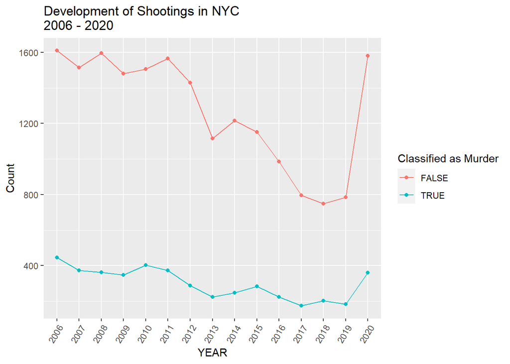

```r
library(ggplot2)

# Shootings / Deaths
ggplot (nypd_data_shot_death, aes(x=YEAR, y=n, color=STATISTICAL_MURDER_FLAG, group=STATISTICAL_MURDER_FLAG))+
  geom_point()+
  geom_line()+
  ggtitle("Development of Shootings in NYC\n2006 - 2020") +
  ylab("Count") +
  labs(color = "Classified as Murder") +
  theme(axis.text.x = element_text(angle = 60, hjust = 1))
```

## 2.2 Age Groups

Next, we want to see if a specific age group is most often affected by shootings. You can see that this is true for the 18-24 and 25-44 olds in the plot. Unfortunately, the range is pretty big. For further analysis, you would need the age structure in NYC to better understand how much of the population the age group represents.

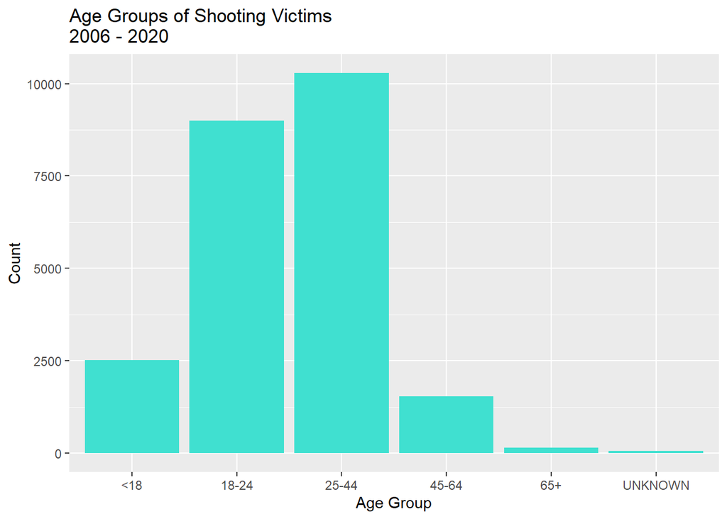

```r
# Age Group
ggplot(nypd_data, aes(VIC_AGE_GROUP))+
  geom_bar(fill = "turquoise")+
  ggtitle("Age Groups of Shooting Victims\n2006 - 2020")+
  xlab("Age Group")+
  ylab("Count")
```

## 2.3 Boroughs

You can identify the two boroughs where most shootings occur at the different boroughs. These boroughs are Bronx and Brooklyn. For further analysis, we would need the census data to compare population density, age distribution, household income, level of education, etc., with the other boroughs.

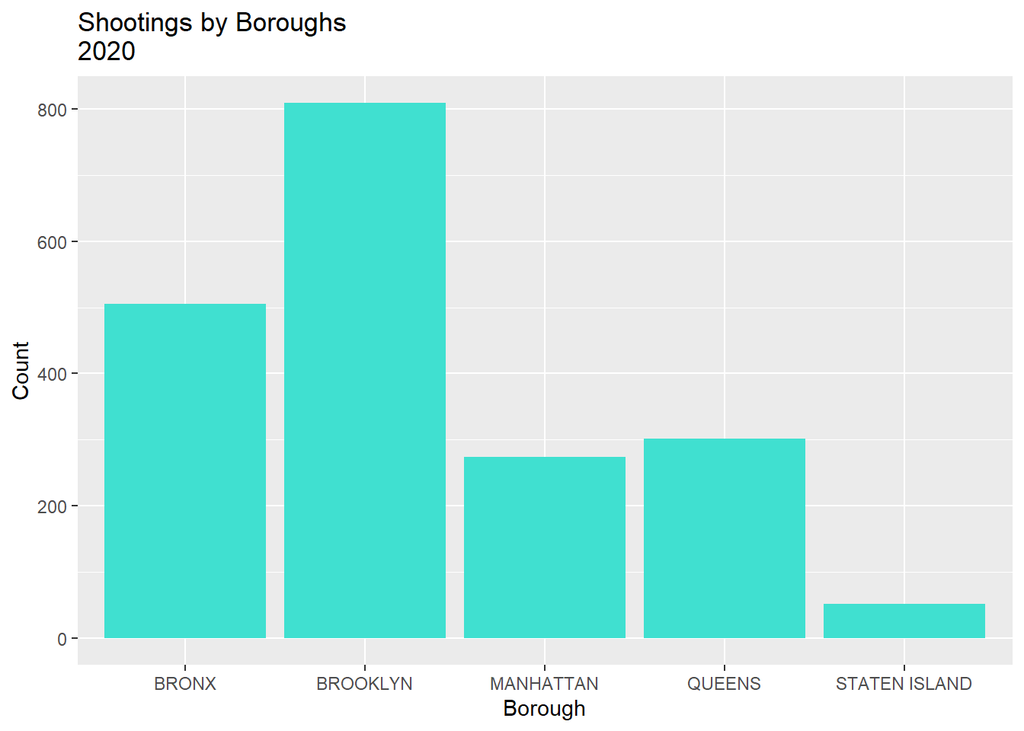

```r
# Top Districts in 2020
ggplot (nypd_top_destination, aes(x=BORO))+
  geom_bar(fill = "turquoise")+
  ggtitle("Shootings by Boroughs\n2020")+
  xlab("Borough")+
  ylab("Count")
```

## 2.4 Time of the Year

We can see a spike in summer and fewer shootings in winter. The reasons for that would need further data about the individuals’ daily activities and moving patterns.

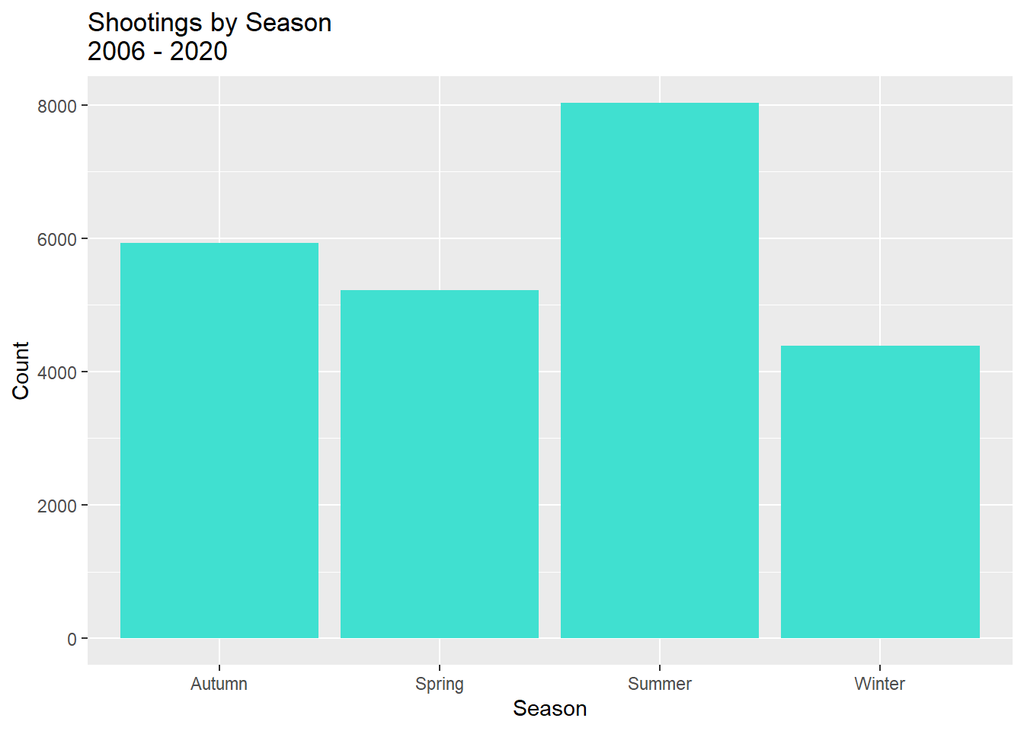

```r
# Top Time of the year
ggplot (nypd_top_season, aes(x=SEASON))+
  geom_bar(fill = "turquoise")+
  ggtitle("Shootings by Season\n2006 - 2020")+
  xlab("Season")+
  ylab("Count")
```

## 2.5 Daytime

There is a clear indication that most shootings occur during the night and the least during the morning. This makes intuitive sense but would require further analysis.

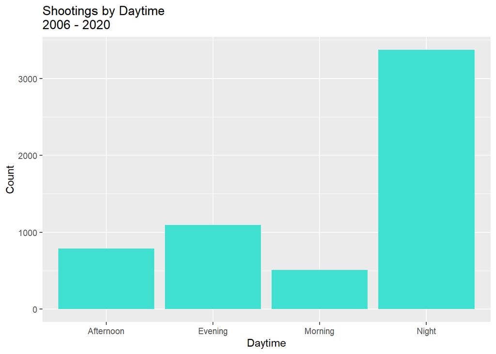

```r
# Top Daytime
ggplot(nypd_top_Daytime , aes(x=DAYTIME))+
  geom_bar(fill = "turquoise")+
  ggtitle("Shootings by Daytime\n2006 - 2020")+
  xlab("Daytime")+
  ylab("Count")
```

## 2.6 Victim Gender

By looking at the victims’ gender, you can see that more men are among the victims. This would need further research and information from census and sociologist

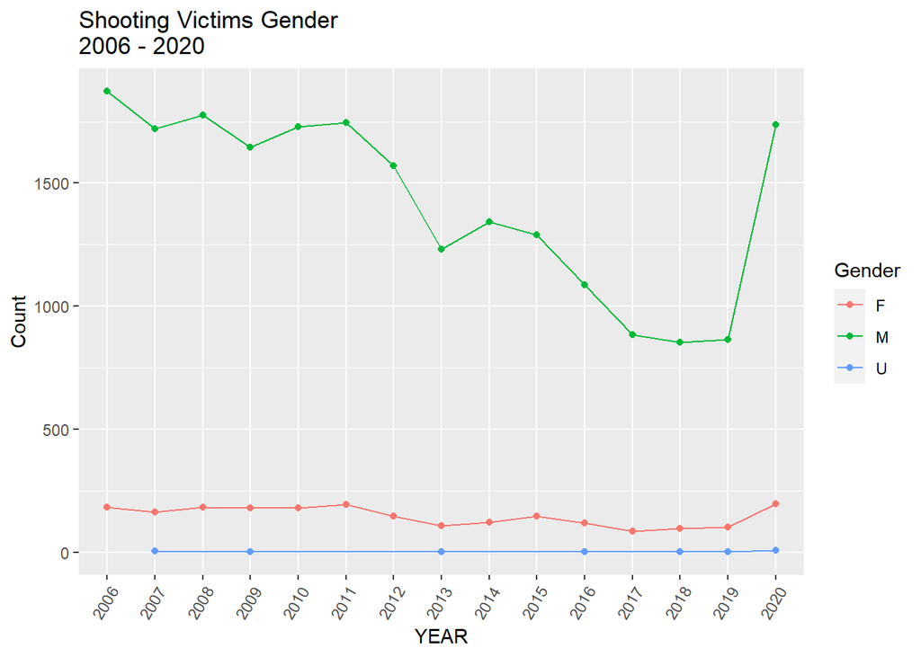

```r
# victims Male, Female, U
ggplot (nypd_data_year_victims, aes(x=YEAR, y=n, color=VIC_SEX, group=VIC_SEX))+
  geom_point()+
  geom_line()+
  ggtitle("Shooting Victims Gender\n2006 - 2020") +
  ylab("Count") +
  labs(color = "Gender") +
  theme(axis.text.x = element_text(angle = 60, hjust = 1))
```

# 3 Plots

After getting an idea about our data we will perform some linear regressions.

## 3.1 Linear Model 1 - Total Shootings / Fatal Shootings

The regression shows that by receiving information about the number of shootings in a given period, we can make reasonable assumptions about the number of fatal shootings. Multiple R-Squared over 0.75 and a p-value below 0.05 suggest that the model has a good fit for our dataset.

```r
# First Model - Numerical / Numerical
mod <- lm(Fatal_Shootings ~ Total_Shootings, data=nypd_data_summary)

summary(mod)
```

```
##
## Call:
## lm(formula = Fatal_Shootings ~ Total_Shootings, data = nypd_data_summary)
##
## Residuals:
##     Min      1Q  Median      3Q     Max
## -42.364 -16.069  -1.058  10.493  45.708
##
## Coefficients:
##                  Estimate Std. Error t value Pr(>|t|)
## (Intercept)     -25.86201   27.32092  -0.947    0.361
## Total_Shootings   0.20689    0.01688  12.260 1.62e-08 ***
## ---
## Signif. codes:  0 '***' 0.001 '**' 0.01 '*' 0.05 '.' 0.1 ' ' 1
##
## Residual standard error: 25.52 on 13 degrees of freedom
## Multiple R-squared:  0.9204, Adjusted R-squared:  0.9143
## F-statistic: 150.3 on 1 and 13 DF,  p-value: 1.616e-08
```

```r
lm_model_nypda_data <-  nypd_data_summary %>%
  mutate(pred_fatal_shootings = predict(mod))
```

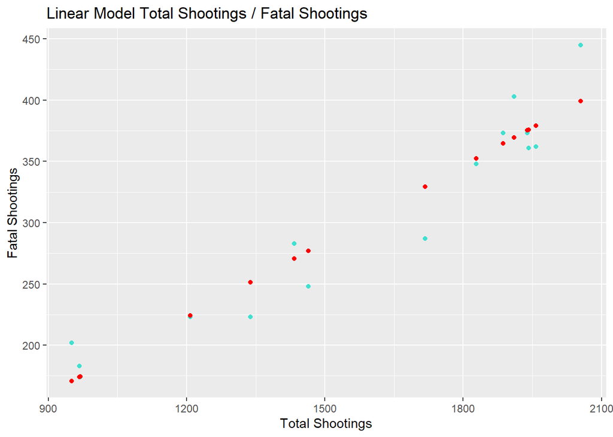

```r
lm_model_nypda_data %>% ggplot() +
  geom_point(aes(x= Total_Shootings, y= Fatal_Shootings), color = "turquoise")+
  geom_point(aes(x= Total_Shootings, y= pred_fatal_shootings), color = "red")+
  ggtitle("Linear Model Total Shootings / Fatal Shootings") +
  ylab("Fatal Shootings") +
  xlab("Total Shootings")
```

## 3.2 Linear Model 2 - Total Shootings / Male Victims

The regression shows that by receiving information about the number of shootings in a given period, we can make reasonable assumptions about the number of male victoms. Multiple R-Squared over 0.75 and a p-value below 0.05 suggest that the model has a good fit for our dataset.

```r
# Second Model - Numerical/ Numerical

mod2 <- lm(Male_victims ~ Total_Shootings, data=nypd_data_summary2)

summary(mod2)
```

```
##
## Call:
## lm(formula = Male_victims ~ Total_Shootings, data = nypd_data_summary2)
##
## Residuals:
##      Min       1Q   Median       3Q      Max
## -10.8447  -0.8447   0.2543   1.0121   6.7855
##
## Coefficients:
##                 Estimate Std. Error t value Pr(>|t|)
## (Intercept)     0.131161   0.095520   1.373     0.17
## Total_Shootings 0.901041   0.002742 328.584   <2e-16 ***
## ---
## Signif. codes:  0 '***' 0.001 '**' 0.01 '*' 0.05 '.' 0.1 ' ' 1
##
## Residual standard error: 1.867 on 892 degrees of freedom
## Multiple R-squared:  0.9918, Adjusted R-squared:  0.9918
## F-statistic: 1.08e+05 on 1 and 892 DF,  p-value: < 2.2e-16
```

```r
lm_model_nypda_data_two <-  nypd_data_summary2 %>%
  mutate(pred_male_vic = predict(mod2))
```

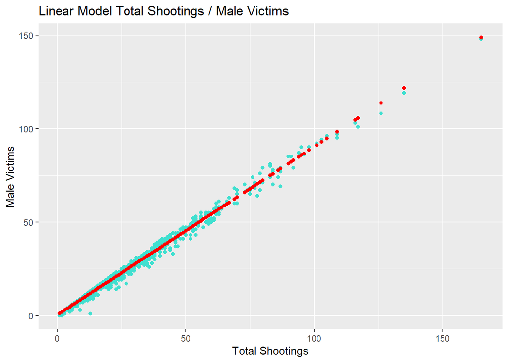

```r
# refers to shootings per month

lm_model_nypda_data_two %>% ggplot() +
  geom_point(aes(x= Total_Shootings, y= Male_victims), color = "turquoise")+
  geom_point(aes(x= Total_Shootings, y= pred_male_vic), color = "red")+
  ggtitle("Linear Model Total Shootings / Male Victims") +
  ylab("Male Victims") +
  xlab("Total Shootings")
```

## 3.3 Linear Model 3 - Boroughs / Total Shootings

The regression shows that by receiving information about the borough we can make assumptions about the number of shootings. Multiple R-Squared below 0.75 suggest that the model has room for improvement. Other factors from different data sources could improve the model.

```r
# Third Model - Categorical / Numerical

mod3 <- lm(Total_Shootings ~ factor(BORO), data=nypd_data_summary2)

summary(mod3)
```

```
##
## Call:
## lm(formula = Total_Shootings ~ factor(BORO), data = nypd_data_summary2)
##
## Residuals:
##     Min      1Q  Median      3Q     Max
## -40.011  -7.228  -1.011   4.772 110.989
##
## Coefficients:
##                           Estimate Std. Error t value Pr(>|t|)
## (Intercept)                 37.222      1.092   34.07   <2e-16 ***
## factor(BORO)BROOKLYN        16.789      1.545   10.87   <2e-16 ***
## factor(BORO)MANHATTAN      -20.994      1.545  -13.59   <2e-16 ***
## factor(BORO)QUEENS         -17.628      1.545  -11.41   <2e-16 ***
## factor(BORO)STATEN ISLAND  -33.211      1.558  -21.31   <2e-16 ***
## ---
## Signif. codes:  0 '***' 0.001 '**' 0.01 '*' 0.05 '.' 0.1 ' ' 1
##
## Residual standard error: 14.66 on 889 degrees of freedom
## Multiple R-squared:  0.588,  Adjusted R-squared:  0.5861
## F-statistic: 317.1 on 4 and 889 DF,  p-value: < 2.2e-16
```

```r
lm_model_nypda_data_three <-  nypd_data_summary2 %>%
  mutate(pred_to_shoot = predict(mod3))
```

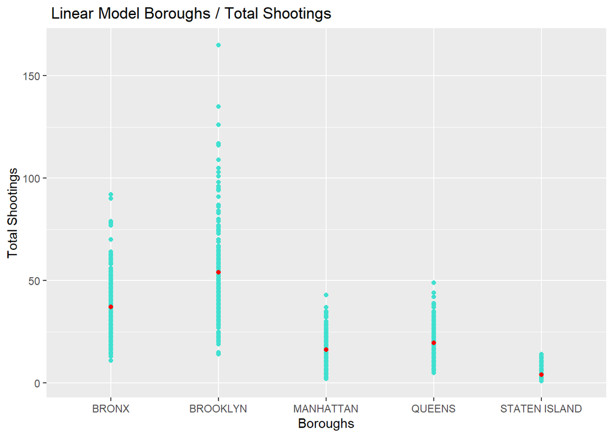

```r
# refers to shootings per month

lm_model_nypda_data_three %>% ggplot() +
  geom_point(aes(x= BORO, y= Total_Shootings), color = "turquoise")+
  geom_point(aes(x= BORO, y= pred_to_shoot), color = "red")+
  ggtitle(" Linear Model Boroughs / Total Shootings") +
  ylab("Total Shootings") +
  xlab("Boroughs")
```

# 4 Conclusion

By analyzing the data, we could figure out that the number of shootings rose in 2020 after being in decline since 2006.

We could see that the age groups most often affected by shootings are the 18-24 and 25-44 olds.

By looking at the victims’ gender, we could figure out that more men are among the victims than women.

We could figure out that total shootings are a good estimator for fatal shootings and male victims by doing regression analysis. At the same time, the borough is not such a robust estimator for the total amount of shootings.

# 5 Bias

Typical source for bias could be confirmation bias. This bias occurs when the person performing the data analysis wants to prove a predetermined assumption. To mitigate that risk, I followed a transparent process and was making conclusions only on the data in the existing data source.

Furthermore, there could have been a bias while collecting the data. I clearly showed where I got the data from and how I was performing the analysis. Every person can follow each step of my activities and evaluate the source. Of course, I can not determine how the data was collected by the NYPD and how biased the persons collecting the data have been.